# Bellabeat Case Study

Leonard Kakinuma

First created on November 18, 2024. Updated on November 18, 2024

# Case Study 2: Bellabeat Data Analysis

## Introduction

Welcome to the second case study of the Google Data Analytics Professional Certificate! In this scenario, you are a junior data analyst working on the marketing analyst team at Bellabeat, a high-tech manufacturer of health-focused products for women.

**In their journey to grow in the global smart device market, Bellabeat has created several products:**

- **Bellabeat app**: The Bellabeat app provides users with health data related to their activity, sleep, stress, menstrual cycle, and mindfulness habits. This data can help users better understand their current habits and make healthy decisions. The Bellabeat app connects to their line of smart wellness products.
- **Leaf**: Bellabeat’s classic wellness tracker can be worn as a bracelet, necklace, or clip. The Leaf tracker connects to the Bellabeat app to track activity, sleep, and stress.
- **Time**: This wellness watch combines the timeless look of a classic timepiece with smart technology to track user activity, sleep, and stress. The Time watch connects to the Bellabeat app to provide you with insights into your daily wellness.
- **Spring**: This is a water bottle that tracks daily water intake using smart technology to ensure that you are appropriately hydrated throughout the day. The Spring bottle connects to the Bellabeat app to track your hydration levels.
- **Bellabeat membership**: Bellabeat also offers a subscription-based membership program for users. Membership gives users 24/7 access to fully personalized guidance on nutrition, activity, sleep, health and beauty, and mindfulness based on their lifestyle and goals.

Bellabeat is a successful small company, but they have the potential to become a larger player in the global smart device market. **Urška Sršen**, cofounder and Chief Creative Officer of Bellabeat, believes that analyzing smart device fitness data could help unlock new growth opportunities for the company. You have been asked to focus on one of Bellabeat’s products and analyze smart device data to gain insight into how consumers are using their smart devices. The insights you discover will then help guide marketing strategy for the company.

In order to answer the key business questions, you will follow the six steps of the data analysis process: **ask, prepare, process, analyze, share, and act**.

## Ask

What are the goals of this case study?

Sršen asks you to analyze smart device usage data in order to gain insight into how consumers use non-Bellabeat smart devices. She then wants you to select one Bellabeat product to apply these insights to in your presentation.

In order to address the business task, you must use the following three questions to guide your analysis:

1. What are some trends in smart device usage?
2. How could these trends apply to Bellabeat customers?
3. How could these trends help influence Bellabeat marketing strategy?

## Prepare

In order to prepare the dataset for analysis, the following steps must be taken:

1. Download data and store it appropriately.
2. Identify how it’s organized.
3. Sort and filter the data.
4. Determine the credibility of the data.

I will do so using the R, a powerful tool that can process datasets, create clear visualizations, and present key points via R Markdown, a notebook interface that can produce high quality, interactive documents in a multitude of formats, such as this PDF file.

### Installing and Loading Packages

While R is incredibly useful, it requires certain packages to streamline operations, which we can install using the `install.packages()` function.

```r
# Installing packages with install.packages()
if(!require(dplyr)) install.packages("dplyr")
if(!require(janitor)) install.packages("janitor")
if(!require(tidyverse)) install.packages("tidyverse")
```

```r
if(!require(lubridate)) install.packages("lubridate")
if(!require(ggplot2)) install.packages("ggplot2")
if(!require(skimr)) install.packages("skimr")
```

In addition, we must load these packages using the `library()` function.

```r
# Loading packages with library()
library("dplyr")
library("janitor")
library("tidyverse")
library("lubridate")
library("ggplot2")
library("skimr")
```

We can now import and prepare the data for cleaning. The given data files are separated into two one-month logs of data, split into eleven files each. The file sizes vary widely, from 4 KB to over 87,000 KB. The larger data sets are comprised of mostly minute-based data, with the smallest being 3,200 KB. Although the level of specificity can be useful, it will likely not have a significant effect on the results of this case study. Therefore, it would be wise to avoid importing these data files.

With the minute-based files out of the picture, we can assign each CSV file to its own data frame as shown here:

```r
# Assigning each CSV file to its own data frame
hourly_intensities <- read_csv("hourlyIntensities_merged.csv")
hourly_calories <- read_csv("hourlyCalories_merged.csv")
hourly_steps <- read_csv("hourlySteps_merged.csv")
daily_activity <- read_csv("dailyActivity_merged.csv")
daily_intensities <- read_csv("dailyIntensities_merged.csv")
daily_steps <- read_csv("dailySteps_merged.csv")
daily_calories <- read_csv("dailyCalories_merged.csv")
daily_sleep <- read_csv("sleepDay_merged.csv")
weight_log <- read_csv("weightLogInfo_merged.csv")
```

## Process

### Inspecting our Data

Now that we have our set of data frames, let’s create some tibbles and inspect the first few rows using `head()`:

```r
# Inspecting each data frame
head(hourly_intensities)
```

```
## # A tibble: 6 × 4
##           Id ActivityHour          TotalIntensity AverageIntensity
##        <dbl> <chr>                          <dbl>            <dbl>
## 1 1503960366 4/12/2016 12:00:00 AM             20            0.333
## 2 1503960366 4/12/2016 1:00:00 AM               8            0.133
## 3 1503960366 4/12/2016 2:00:00 AM               7            0.117
## 4 1503960366 4/12/2016 3:00:00 AM               0            0
## 5 1503960366 4/12/2016 4:00:00 AM               0            0
## 6 1503960366 4/12/2016 5:00:00 AM               0            0
```

```r
head(hourly_calories)
```

```
## # A tibble: 6 × 3
##           Id ActivityHour          Calories
##        <dbl> <chr>                    <dbl>
## 1 1503960366 4/12/2016 12:00:00 AM       81
## 2 1503960366 4/12/2016 1:00:00 AM        61
## 3 1503960366 4/12/2016 2:00:00 AM        59
## 4 1503960366 4/12/2016 3:00:00 AM        47
## 5 1503960366 4/12/2016 4:00:00 AM        48
## 6 1503960366 4/12/2016 5:00:00 AM        48
```

```r
head(hourly_steps)
```

```
## # A tibble: 6 × 3
##           Id ActivityHour          StepTotal
##        <dbl> <chr>                     <dbl>
## 1 1503960366 4/12/2016 12:00:00 AM       373
## 2 1503960366 4/12/2016 1:00:00 AM        160
## 3 1503960366 4/12/2016 2:00:00 AM        151
## 4 1503960366 4/12/2016 3:00:00 AM          0
## 5 1503960366 4/12/2016 4:00:00 AM          0
## 6 1503960366 4/12/2016 5:00:00 AM          0
```

```r
head(daily_activity)
```

```
## # A tibble: 6 × 15
##           Id ActivityDate TotalSteps TotalDistance TrackerDistance
##        <dbl> <chr>             <dbl>         <dbl>           <dbl>
## 1 1503960366 4/12/2016         13162          8.5             8.5
## 2 1503960366 4/13/2016         10735          6.97            6.97
## 3 1503960366 4/14/2016         10460          6.74            6.74
## 4 1503960366 4/15/2016          9762          6.28            6.28
## 5 1503960366 4/16/2016         12669          8.16            8.16
## 6 1503960366 4/17/2016          9705          6.48            6.48
## # ℹ 10 more variables: LoggedActivitiesDistance <dbl>,
## #   VeryActiveDistance <dbl>, ModeratelyActiveDistance <dbl>,
## #   LightActiveDistance <dbl>, SedentaryActiveDistance <dbl>,
## #   VeryActiveMinutes <dbl>, FairlyActiveMinutes <dbl>,
## #   LightlyActiveMinutes <dbl>, SedentaryMinutes <dbl>, Calories <dbl>
```

```r
head(daily_intensities)
```

```
## # A tibble: 6 × 10
##         Id ActivityDay SedentaryMinutes LightlyActiveMinutes FairlyActiveMinutes
##      <dbl> <chr>                  <dbl>                <dbl>               <dbl>
## 1   1.50e9 4/12/2016                728                  328                  13
## 2   1.50e9 4/13/2016                776                  217                  19
## 3   1.50e9 4/14/2016               1218                  181                  11
## 4   1.50e9 4/15/2016                726                  209                  34
## 5   1.50e9 4/16/2016                773                  221                  10
## 6   1.50e9 4/17/2016                539                  164                  20
## # ℹ 5 more variables: VeryActiveMinutes <dbl>, SedentaryActiveDistance <dbl>,
## #   LightActiveDistance <dbl>, ModeratelyActiveDistance <dbl>,
## #   VeryActiveDistance <dbl>
```

```r
head(daily_steps)
```

```
## # A tibble: 6 × 3
##           Id ActivityDay StepTotal
##        <dbl> <chr>           <dbl>
## 1 1503960366 4/12/2016       13162
## 2 1503960366 4/13/2016       10735
## 3 1503960366 4/14/2016       10460
## 4 1503960366 4/15/2016        9762
## 5 1503960366 4/16/2016       12669
## 6 1503960366 4/17/2016        9705
```

```r
head(daily_calories)
```

```
## # A tibble: 6 × 3
##           Id ActivityDay Calories
##        <dbl> <chr>          <dbl>
## 1 1503960366 4/12/2016       1985
## 2 1503960366 4/13/2016       1797
## 3 1503960366 4/14/2016       1776
## 4 1503960366 4/15/2016       1745
## 5 1503960366 4/16/2016       1863
## 6 1503960366 4/17/2016       1728
```

```r
head(daily_sleep)
```

```
## # A tibble: 6 × 5
##           Id SleepDay        TotalSleepRecords TotalMinutesAsleep TotalTimeInBed
##        <dbl> <chr>                       <dbl>              <dbl>          <dbl>
## 1 1503960366 4/12/2016 12:0…                 1                327            346
## 2 1503960366 4/13/2016 12:0…                 2                384            407
## 3 1503960366 4/15/2016 12:0…                 1                412            442
## 4 1503960366 4/16/2016 12:0…                 2                340            367
## 5 1503960366 4/17/2016 12:0…                 1                700            712
## 6 1503960366 4/19/2016 12:0…                 1                304            320
```

```r
head(weight_log)
```

```
## # A tibble: 6 × 8
##           Id Date       WeightKg WeightPounds   Fat   BMI IsManualReport   LogId
##        <dbl> <chr>         <dbl>        <dbl> <dbl> <dbl> <lgl>            <dbl>
## 1 1503960366 5/2/2016 …     52.6         116.    22  22.6 TRUE           1.46e12
## 2 1503960366 5/3/2016 …     52.6         116.    NA  22.6 TRUE           1.46e12
## 3 1927972279 4/13/2016…    134.          294.    NA  47.5 FALSE          1.46e12
## 4 2873212765 4/21/2016…     56.7         125.    NA  21.5 TRUE           1.46e12
## 5 2873212765 5/12/2016…     57.3         126.    NA  21.7 TRUE           1.46e12
## 6 4319703577 4/17/2016…     72.4         160.    25  27.5 TRUE           1.46e12
```

### Column Names

Next, let’s see how the columns are organized using `col()`:

```r
# Seeing how each data frame is organized
colnames(hourly_intensities)
```

```
## [1] "Id"               "ActivityHour"     "TotalIntensity"   "AverageIntensity"
```

```r
colnames(hourly_calories)
```

```
## [1] "Id"           "ActivityHour" "Calories"
```

```r
colnames(hourly_steps)
```

```
## [1] "Id"           "ActivityHour" "StepTotal"
```

```r
colnames(daily_activity)
```

```
##  [1] "Id"                       "ActivityDate"
##  [3] "TotalSteps"               "TotalDistance"
##  [5] "TrackerDistance"          "LoggedActivitiesDistance"
##  [7] "VeryActiveDistance"       "ModeratelyActiveDistance"
##  [9] "LightActiveDistance"      "SedentaryActiveDistance"
## [11] "VeryActiveMinutes"        "FairlyActiveMinutes"
## [13] "LightlyActiveMinutes"     "SedentaryMinutes"
## [15] "Calories"
```

```r
colnames(daily_intensities)
```

```
##  [1] "Id"                       "ActivityDay"
##  [3] "SedentaryMinutes"         "LightlyActiveMinutes"
##  [5] "FairlyActiveMinutes"      "VeryActiveMinutes"
##  [7] "SedentaryActiveDistance"  "LightActiveDistance"
##  [9] "ModeratelyActiveDistance" "VeryActiveDistance"
```

```r
colnames(daily_steps)
```

```
## [1] "Id"          "ActivityDay" "StepTotal"
```

```r
colnames(daily_calories)
```

```
## [1] "Id"          "ActivityDay" "Calories"
```

```r
colnames(daily_sleep)
```

```
## [1] "Id"                 "SleepDay"           "TotalSleepRecords"
## [4] "TotalMinutesAsleep" "TotalTimeInBed"
```

```r
colnames(weight_log)
```

```
## [1] "Id"             "Date"           "WeightKg"       "WeightPounds"
## [5] "Fat"            "BMI"            "IsManualReport" "LogId"
```

### Observations

From the first few rows of each data set as well as the column names, we can make a few observations:

1. The variables are named using pascal case, which capitalizes the first letter of each word.
2. The name of the date column in each file can vary, as most of the files refer to the date as `ActivityDay`, while others may use `SleepDay` or `Date`.
3. The date format differs from file to file, likely due to the method of recording data, as some are based on the hour and others are dependent on the day.

### Cleaning the Data

Before analyzing the data, we must clean it and ensure standardization between data sets by completing these steps:

1. As previously mentioned, the column names utilize pascal case. We can alter the names to use snake case, as per [tidyverse’s style guide](https://style.tidyverse.org/syntax.html), which uses all lowercase characters and underscores to separate words.
2. We can standardize the name of each date column to `date`.
3. We can separate the day of the activity from the hour into two different columns if the data file records both.
4. We can standardize each ‘date’ format to one format. Let’s do the “month-day-year” format

```r
# Changing column names from pascal case to snake case and standardizing date name
hourly_intensities <- hourly_intensities %>%
  rename(
    id = Id,
    date = ActivityHour,
    total_intensity = TotalIntensity,
    average_intensity = AverageIntensity
  )

hourly_calories <- hourly_calories %>%
  rename(
    id = Id,
    date = ActivityHour,
    calories = Calories,
  )

hourly_steps <- hourly_steps %>%
  rename(
    id = Id,
    date = ActivityHour,
    total_steps = StepTotal
  )

daily_activity <- daily_activity %>%
  rename(
    id = Id,
    date = ActivityDate,
    total_steps = TotalSteps,
    total_distance = TotalDistance,
    tracked_distance = TrackerDistance,
    logged_distance = LoggedActivitiesDistance,
    very_active_distance = VeryActiveDistance,
    moderately_active_distance = ModeratelyActiveDistance,
    lightly_active_distance = LightActiveDistance,
    sedentary_active_distance = SedentaryActiveDistance,
    very_active_minutes = VeryActiveMinutes,
    fairly_active_minutes = FairlyActiveMinutes,
    lightly_active_minutes = LightlyActiveMinutes,
    sedentary_minutes = SedentaryMinutes,
    calories = Calories
  )

daily_intensities <- daily_intensities %>%
  rename(
    id = Id,
    date = ActivityDay,
    sedentary_minutes = SedentaryMinutes,
    lightly_active_minutes = LightlyActiveMinutes,
    fairly_active_minutes = FairlyActiveMinutes,
    very_active_minutes = VeryActiveMinutes,
    sedentary_active_distance = SedentaryActiveDistance,
    lightly_active_distance = LightActiveDistance,
    moderately_active_distance = ModeratelyActiveDistance,
    very_active_distance = VeryActiveDistance
  )

daily_steps <- daily_steps %>%
  rename(
    id = Id,
    date = ActivityDay,
    total_steps = StepTotal
  )

daily_calories <- daily_calories %>%
  rename(
    id = Id,
    date = ActivityDay,
    calories = Calories
  )

daily_sleep <- daily_sleep %>%
  rename(
    id = Id,
    date = SleepDay,
    total_sleep_records = TotalSleepRecords,
    total_minutes_asleep = TotalMinutesAsleep,
    total_time_in_bed = TotalTimeInBed
  )

weight_log <- weight_log %>%
  rename(
    id = Id,
    date = Date,
    weight_kg = WeightKg,
    weight_lb = WeightPounds,
    fat = Fat,
    bmi = BMI,
    is_manual_report = IsManualReport,
    log_id = LogId
  )
```

Now that the column and date names have all been standardized, we need to ensure consistency between all of the different date variables. As previously mentioned, this requires separating the `date` of each row from the `time` into two distinct columns:

```r
# Separating date and time, then moving time to be adjacent to date in files.
hourly_intensities <- hourly_intensities %>%
  mutate(
    time = format(as.POSIXct(mdy_hms(hourly_intensities$date)), format = "%H:%M:%S"),
    date = as.Date(hourly_intensities$date, "%m/%d/%Y")
  ) %>%
  relocate(
    time, .after = date
  )
hourly_calories <- hourly_calories %>%
  mutate(
    time = format(as.POSIXct(mdy_hms(hourly_calories$date)), format = "%H:%M:%S"),
    date = as.Date(hourly_calories$date, "%m/%d/%Y")
  ) %>%
  relocate(
    time, .after = date
  )
hourly_steps <- hourly_steps %>%
  mutate(
    time = format(as.POSIXct(mdy_hms(hourly_steps$date)), format = "%H:%M:%S"),
    date = as.Date(hourly_steps$date, "%m/%d/%Y")
  ) %>%
  relocate(
    time, .after = date
  )
daily_sleep <- daily_sleep %>%
  mutate(
    time = format(as.POSIXct(mdy_hms(daily_sleep$date)), format = "%H:%M:%S"),
    date = as.Date(daily_sleep$date, "%m/%d/%Y")
  ) %>%
  relocate(
    time, .after = date
  )
weight_log <- weight_log %>%
  mutate(
    time = format(as.POSIXct(mdy_hms(weight_log$date)), format = "%H:%M:%S"),
    date = as.Date(weight_log$date, "%m/%d/%Y")
  ) %>%
  relocate(
    time, .after = date
  )
```

Time to standardize the ‘date’ format:

```r
daily_activity <- daily_activity  %>%
  mutate(
    date = as.Date(date, format = "%m/%d/%Y")
  )
daily_intensities <- daily_intensities %>%
  mutate(
    date = as.Date(date, format = "%m/%d/%Y")
  )
daily_steps <- daily_steps %>%
  mutate(
    date = as.Date(date, format = "%m/%d/%Y")
  )
daily_calories <- daily_calories %>%
  mutate(
    date = as.Date(date, format = "%m/%d/%Y")
  )
```

Next, let’s get rid of duplicates:

```r
# Dropping duplicates
hourly_intensities <- hourly_intensities %>%
  distinct()
hourly_calories <- hourly_calories %>%
  distinct()
hourly_steps <- hourly_steps %>%
  distinct()
daily_activity <- daily_activity %>%
  distinct()
daily_intensities <- daily_intensities %>%
  distinct()
daily_steps <- daily_steps %>%
  distinct()
daily_calories <- daily_calories %>%
  distinct()
daily_sleep <- daily_sleep %>%
  distinct()
weight_log <- weight_log %>%
  distinct()
```

We can validate that there are no duplicates:

```r
# Checking for duplicates and missing values
cat("hourly_intensities:", sum(duplicated(hourly_intensities)), "duplicates\n")
```

```
## hourly_intensities: 0 duplicates
```

```r
cat("hourly_calories:", sum(duplicated(hourly_calories)), "duplicates\n")
```

```
## hourly_calories: 0 duplicates
```

```r
cat("hourly_steps:", sum(duplicated(hourly_steps)), "duplicates\n")
```

```
## hourly_steps: 0 duplicates
```

```r
cat("daily_activity:", sum(duplicated(daily_activity)), "duplicates\n")
```

```
## daily_activity: 0 duplicates
```

```r
cat("daily_intensities:", sum(duplicated(daily_intensities)), "duplicates\n")
```

```
## daily_intensities: 0 duplicates
```

```r
cat("daily_steps:", sum(duplicated(daily_steps)), "duplicates\n")
```

```
## daily_steps: 0 duplicates
```

```r
cat("daily_calories:", sum(duplicated(daily_calories)), "duplicates\n")
```

```
## daily_calories: 0 duplicates
```

```r
cat("daily_sleep:", sum(duplicated(daily_sleep)), "duplicates\n")
```

```
## daily_sleep: 0 duplicates
```

```r
cat("weight_log:", sum(duplicated(weight_log)), "duplicates\n")
```

```
## weight_log: 0 duplicates
```

## Analyze

### Unique Participants

As we look into each data set, it is important to understand whether the number of participants of each set is sufficient for analysis.

```r
# Finding the number of unique participants in each data set
cat("hourly_intensities:", n_distinct(hourly_intensities$id), "unique participants\n")
```

```
## hourly_intensities: 33 unique participants
```

```r
cat("hourly_calories:", n_distinct(hourly_calories$id), "unique participants\n")
```

```
## hourly_calories: 33 unique participants
```

```r
cat("hourly_steps:", n_distinct(hourly_steps$id), "unique participants\n")
```

```
## hourly_steps: 33 unique participants
```

```r
cat("daily_activity:", n_distinct(daily_activity$id), "unique participants\n")
```

```
## daily_activity: 33 unique participants
```

```r
cat("daily_intensities:", n_distinct(daily_intensities$id), "unique participants\n")
```

```
## daily_intensities: 33 unique participants
```

```r
cat("daily_steps:", n_distinct(daily_steps$id), "unique participants\n")
```

```
## daily_steps: 33 unique participants
```

```r
cat("daily_calories:", n_distinct(daily_calories$id), "unique participants\n")
```

```
## daily_calories: 33 unique participants
```

```r
cat("daily_sleep:", n_distinct(daily_sleep$id), "unique participants\n")
```

```
## daily_sleep: 24 unique participants
```

```r
cat("weight_log:", n_distinct(weight_log$id), "unique participants\n")
```

```
## weight_log: 8 unique participants
```

Almost all of the data sets have the same amount of distinct participants, however, `daily_sleep` and `weight_log` have significantly less. In particular, `weight_log` only features 8 participants. As a result, we should avoid analyzing this data set as the sample size is too small and even one outlier could skew analysis heavily.

### Summary Statistics

Before we dive into comparing specific columns of each data set, let’s get an overview of the summary statistics using `summary()`:

```r
# Summary Statistics
hourly_intensities %>%
  select(
    total_intensity,
    average_intensity
  ) %>%
  summary()
```

```
##  total_intensity  average_intensity
##  Min.   :  0.00   Min.   :0.0000
##  1st Qu.:  0.00   1st Qu.:0.0000
##  Median :  3.00   Median :0.0500
##  Mean   : 12.04   Mean   :0.2006
##  3rd Qu.: 16.00   3rd Qu.:0.2667
##  Max.   :180.00   Max.   :3.0000
```

```r
hourly_calories %>%
  select(
    calories
  ) %>%
  summary()
```

```
##     calories
##  Min.   : 42.00
##  1st Qu.: 63.00
##  Median : 83.00
##  Mean   : 97.39
##  3rd Qu.:108.00
##  Max.   :948.00
```

```r
hourly_steps %>%
  select(
    total_steps
  ) %>%
  summary()
```

```
##   total_steps
##  Min.   :    0.0
##  1st Qu.:    0.0
##  Median :   40.0
##  Mean   :  320.2
##  3rd Qu.:  357.0
##  Max.   :10554.0
```

```r
daily_activity %>%
  select(
    total_distance,
    tracked_distance,
    logged_distance,
  ) %>%
  summary()
```

```
##  total_distance   tracked_distance logged_distance
##  Min.   : 0.000   Min.   : 0.000   Min.   :0.0000
##  1st Qu.: 2.620   1st Qu.: 2.620   1st Qu.:0.0000
##  Median : 5.245   Median : 5.245   Median :0.0000
##  Mean   : 5.490   Mean   : 5.475   Mean   :0.1082
##  3rd Qu.: 7.713   3rd Qu.: 7.710   3rd Qu.:0.0000
##  Max.   :28.030   Max.   :28.030   Max.   :4.9421
```

```r
daily_intensities %>%
  select(
    sedentary_minutes,
    lightly_active_minutes,
    fairly_active_minutes,
    very_active_minutes,
    sedentary_active_distance,
    lightly_active_distance,
    moderately_active_distance,
    very_active_distance
  ) %>%
  summary()
```

```
##  sedentary_minutes lightly_active_minutes fairly_active_minutes
##  Min.   :   0.0    Min.   :  0.0          Min.   :  0.00
##  1st Qu.: 729.8    1st Qu.:127.0          1st Qu.:  0.00
##  Median :1057.5    Median :199.0          Median :  6.00
##  Mean   : 991.2    Mean   :192.8          Mean   : 13.56
##  3rd Qu.:1229.5    3rd Qu.:264.0          3rd Qu.: 19.00
##  Max.   :1440.0    Max.   :518.0          Max.   :143.00
##  very_active_minutes sedentary_active_distance lightly_active_distance
##  Min.   :  0.00      Min.   :0.000000          Min.   : 0.000
##  1st Qu.:  0.00      1st Qu.:0.000000          1st Qu.: 1.945
##  Median :  4.00      Median :0.000000          Median : 3.365
##  Mean   : 21.16      Mean   :0.001606          Mean   : 3.341
##  3rd Qu.: 32.00      3rd Qu.:0.000000          3rd Qu.: 4.782
##  Max.   :210.00      Max.   :0.110000          Max.   :10.710
##  moderately_active_distance very_active_distance
##  Min.   :0.0000             Min.   : 0.000
##  1st Qu.:0.0000             1st Qu.: 0.000
##  Median :0.2400             Median : 0.210
##  Mean   :0.5675             Mean   : 1.503
##  3rd Qu.:0.8000             3rd Qu.: 2.053
##  Max.   :6.4800             Max.   :21.920
```

```r
daily_steps %>%
  select(
    total_steps
  ) %>%
  summary()
```

```
##   total_steps
##  Min.   :    0
##  1st Qu.: 3790
##  Median : 7406
##  Mean   : 7638
##  3rd Qu.:10727
##  Max.   :36019
```

```r
daily_calories %>%
  select(
    calories
  ) %>%
  summary()
```

```
##     calories
##  Min.   :   0
##  1st Qu.:1828
##  Median :2134
##  Mean   :2304
##  3rd Qu.:2793
##  Max.   :4900
```

```r
daily_sleep %>%
  select(
    total_sleep_records,
    total_minutes_asleep,
    total_time_in_bed
  ) %>%
  summary()
```

```
##  total_sleep_records total_minutes_asleep total_time_in_bed
##  Min.   :1.00        Min.   : 58.0        Min.   : 61.0
##  1st Qu.:1.00        1st Qu.:361.0        1st Qu.:403.8
##  Median :1.00        Median :432.5        Median :463.0
##  Mean   :1.12        Mean   :419.2        Mean   :458.5
##  3rd Qu.:1.00        3rd Qu.:490.0        3rd Qu.:526.0
##  Max.   :3.00        Max.   :796.0        Max.   :961.0
```

```r
weight_log %>%
  select(
    weight_lb,
    fat,
    bmi
  ) %>%
  summary()
```

```
##    weight_lb          fat             bmi
##  Min.   :116.0   Min.   :22.00   Min.   :21.45
##  1st Qu.:135.4   1st Qu.:22.75   1st Qu.:23.96
##  Median :137.8   Median :23.50   Median :24.39
##  Mean   :158.8   Mean   :23.50   Mean   :25.19
##  3rd Qu.:187.5   3rd Qu.:24.25   3rd Qu.:25.56
##  Max.   :294.3   Max.   :25.00   Max.   :47.54
##                  NA's   :65
```

We can make a few observations based on these summary statistics about this sample group:

- The median sleep time is **7.21 hours**, which is more than the [CDC’s recommended amount of sleep for adults](https://www.cdc.gov/sleep/data-research/facts-stats/adults-sleep-facts-and-stats.html#:~:text=The%20recommended%20amount%20of%20sleep,Getting%20insufficient%20sleep.).
- **7,406** is the median amount of steps, which is well below the [10,000](https://www.cdc.gov/pcd/issues/2016/pdf/16_0111.pdf) steps commonly cited as a daily goal.
- The median sedentary time is **17.63 hours**. If sleep is removed from this number, the amount is still incredibly high, at **10.42 hours**. [High sedentary activity can increase the risk of type-2 diabetes, cancer, and heart disease](https://www.who.int/europe/publications/i/item/9789240014886).
- The combined total of median fairly active minutes and very active minutes is only **70 minutes** a week, a number well below the [recommended](https://www.who.int/publications/i/item/9789241599979) **150** minutes of moderately active activity or **75** minutes of very active activity.

### Visualizing Basic Trends

While some general statistics can be derived from the given FitBit dataset, we should dive deeper into the data and find more trends from comparing different variables.

One key data point we can use to guide our takeaways from this dataset is the calories column. Using the `calories` column, we can track the effectiveness of the different measurements listed in the dataset. One such measurement is the amount of daily steps. Let’s graph the relationship between `total_steps` and `calories`.

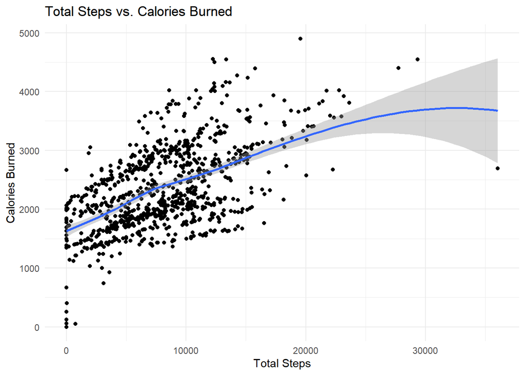

```r
# Visualizing total_steps vs. calories
daily_activity %>%
  ggplot(aes(x = total_steps, y = calories)) +
  geom_point() +
  geom_smooth() +
  theme_minimal() +
  labs(title = "Total Steps vs. Calories Burned") +
  xlab("Total Steps") +
  ylab("Calories Burned")
```

As expected, the graph illustrates that there is a clear correllation between calories burned and total steps on a day-to-day basis.

However, is this the same with different levels of activity? Let’s compare the time spent on each level of activity with the daily calories.

First, we can start from `sedentary_minutes` and make our way towards `very_active_minutes`.

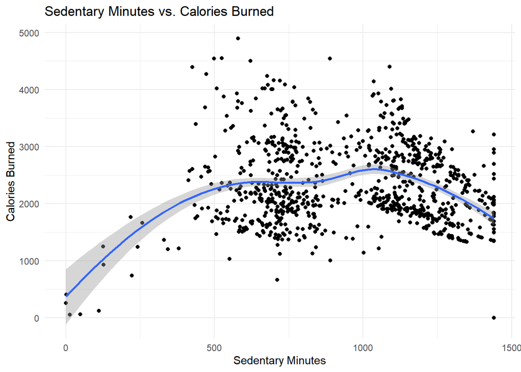

```r
# Visualizing sedentary_minutes vs. calories
daily_activity %>%
  ggplot(aes(x = sedentary_minutes, y = calories)) +
  geom_point() +
  geom_smooth() +
  theme_minimal() +
  labs(title = "Sedentary Minutes vs. Calories Burned") +
  xlab("Sedentary Minutes") +
  ylab("Calories Burned")
```

Unsurprisingly, `sedentary_minutes` does not seem to significantly increase the total calories burned, as it includes time spent sleeping. However, the downwards trend near the end of the graph demonstrates that as it takes up more of a person’s day, `sedentary_minutes` can take away from time spent on strenous activity, reducing the amount of calories burned.

Next, let’s inspect `lightly_active_minutes` vs. `calories`:

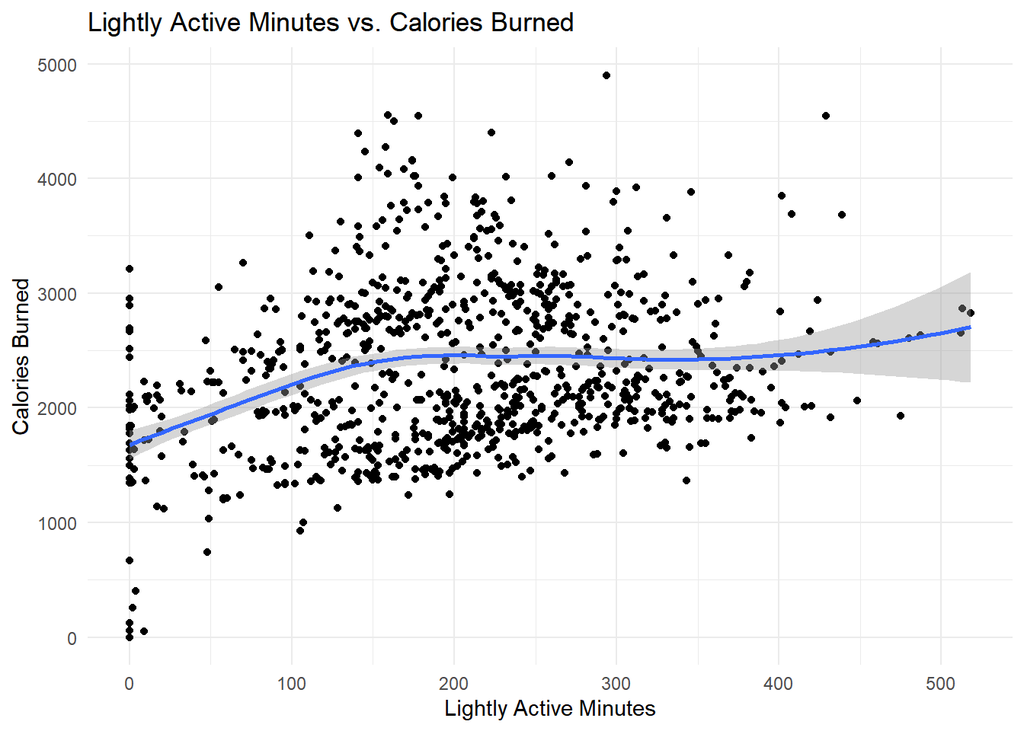

```r
# Visualizing lightly_active_minutes vs. calories
daily_activity %>%
  ggplot(aes(x = lightly_active_minutes, y = calories)) +
  geom_point() +
  geom_smooth() +
  theme_minimal() +
  labs(title = "Lightly Active Minutes vs. Calories Burned") +
  xlab("Lightly Active Minutes") +
  ylab("Calories Burned")
```

Similar to the `sedentary_minutes` vs `calories` graph, `lightly_active_minutes` does not seem to have a significant positive increase on daily calories burned. However, unlike sedentary activity, light physical activity does seem to not hamper total calories burned.

Next, we can visualize the effect `fairly_active_minutes` has on `calories`:

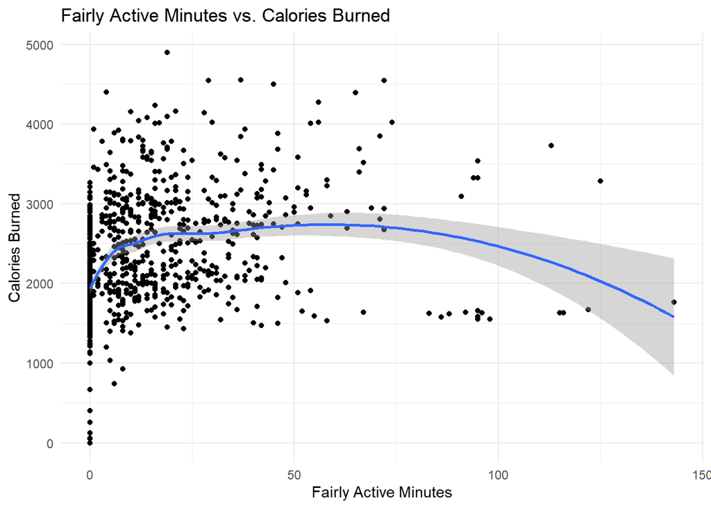

```r
# Visualizing fairly_active_minutes vs. calories
daily_activity %>%
  ggplot(aes(x = fairly_active_minutes, y = calories)) +
  geom_point() +
  geom_smooth() +
  theme_minimal() +
  labs(title = "Fairly Active Minutes vs. Calories Burned") +
  xlab("Fairly Active Minutes") +
  ylab("Calories Burned")
```

The trend line at the beginning section of the graph, where the majority of data points are located, indicates that fairly active physical activity can have some impact on total daily calories, however, it seems more limited in its effect. Nonetheless, it appears to have a marginally higher impact than lightly active physical activity.

Finally, let’s visualize how `very_active_minutes` effects `calories`:

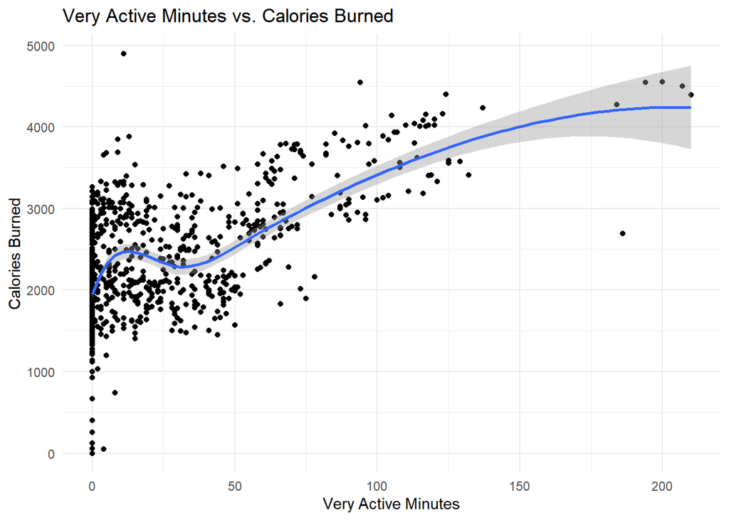

```r
# Visualizing very_active_minutes vs. calories
daily_activity %>%
  ggplot(aes(x = very_active_minutes, y = calories)) +
  geom_point() +
  geom_smooth() +
  theme_minimal() +
  labs(title = "Very Active Minutes vs. Calories Burned") +
  xlab("Very Active Minutes") +
  ylab("Calories Burned")
```

From this graph, we can see that `very_active_minutes` has a significant impact on `calories`. The consequences of very active activity is substantially higher than all other forms of physical activity, reflected in the trend line.

### Trends on each Day of the Week

Now that we can be fairly certain that the activity level has a high impact on calories burned, let’s dive deeper into the different variables that can affect each user.

One variable that could have a potential impact is the day of the week. Each day of the week could each play a significant role in each user’s physical activity level for that day. For example, Mondays, which are typically followed by a workday on Tuesday, might leave less free time than a Friday, where users usually do not have to worry about working the next day.

To inspect this aspect of the data, we should create a new variable categorizing activity into a certain day:

```r
# Adding a new column for the day of the week to each dataset
daily_activity <- daily_activity %>%
  mutate(
    day_of_week = weekdays(daily_activity$date)
  ) %>%
  relocate(
    day_of_week, .after = date
  )
hourly_intensities <- hourly_intensities %>%
  mutate(
    day_of_week = weekdays(hourly_intensities$date)
  ) %>%
  relocate(
    day_of_week, .after = date
  )
hourly_calories <- hourly_calories %>%
  mutate(
    day_of_week = weekdays(hourly_calories$date)
  ) %>%
  relocate(
    day_of_week, .after = date
  )
hourly_steps <- hourly_steps %>%
  mutate(
    day_of_week = weekdays(hourly_steps$date)
  ) %>%
  relocate(
    day_of_week, .after = date
  )
daily_intensities <- daily_intensities %>%
  mutate(
    day_of_week = weekdays(daily_intensities$date)
  ) %>%
  relocate(
    day_of_week, .after = date
  )
daily_steps <- daily_steps %>%
  mutate(
    day_of_week = weekdays(daily_steps$date)
  ) %>%
  relocate(
    day_of_week, .after = date
  )
daily_calories <- daily_calories %>%
  mutate(
    day_of_week = weekdays(daily_calories$date)
  ) %>%
  relocate(
    day_of_week, .after = date
  )
daily_sleep  <- daily_sleep %>%
  mutate(
    day_of_week = weekdays(daily_sleep$date)
  ) %>%
  relocate(
    day_of_week, .after = date
  )
weight_log <- weight_log %>%
  mutate(
    day_of_week = weekdays(weight_log$date)
  ) %>%
  relocate(
    day_of_week, .after = date
  )
```

Then we can visualize activity levels vs. `day_of_week`:

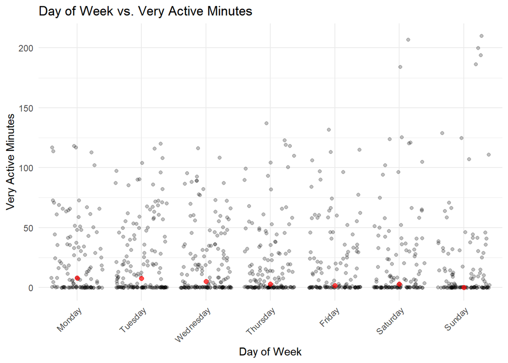

```r
# Visualizing activity levels vs. `day_of_week`
day_of_week_ordered <- factor(
  daily_activity$day_of_week,
  levels = c("Monday", "Tuesday", "Wednesday", "Thursday", "Friday", "Saturday", "Sunday")
  )
daily_activity %>%
  ggplot(aes(x = day_of_week_ordered, y = very_active_minutes)) +
  geom_point(position = "jitter", alpha = 0.25) +
  geom_smooth() +
  theme_minimal() +
  labs(title = "Day of Week vs. Very Active Minutes") +
  xlab("Day of Week") +
  ylab("Very Active Minutes") +
  stat_summary(
    geom = "point",
    fun = median,
    color = "red",
    size = 2,
    alpha = 0.7
  ) +
  theme(axis.text.x = element_text(angle=45, vjust=1, hjust=1))
```

We can see that `very_active_minutes` actually drops on Friday, Saturday, and Sunday, where people usually have more free time. This could be due to a priority on spending time outside of high physical activity, focusing on social activities instead. With that said, the actual difference in time spent on very active activity is not significant enough to create a noticeable trend.

Next, let’s look at calories burned on each day of the week:

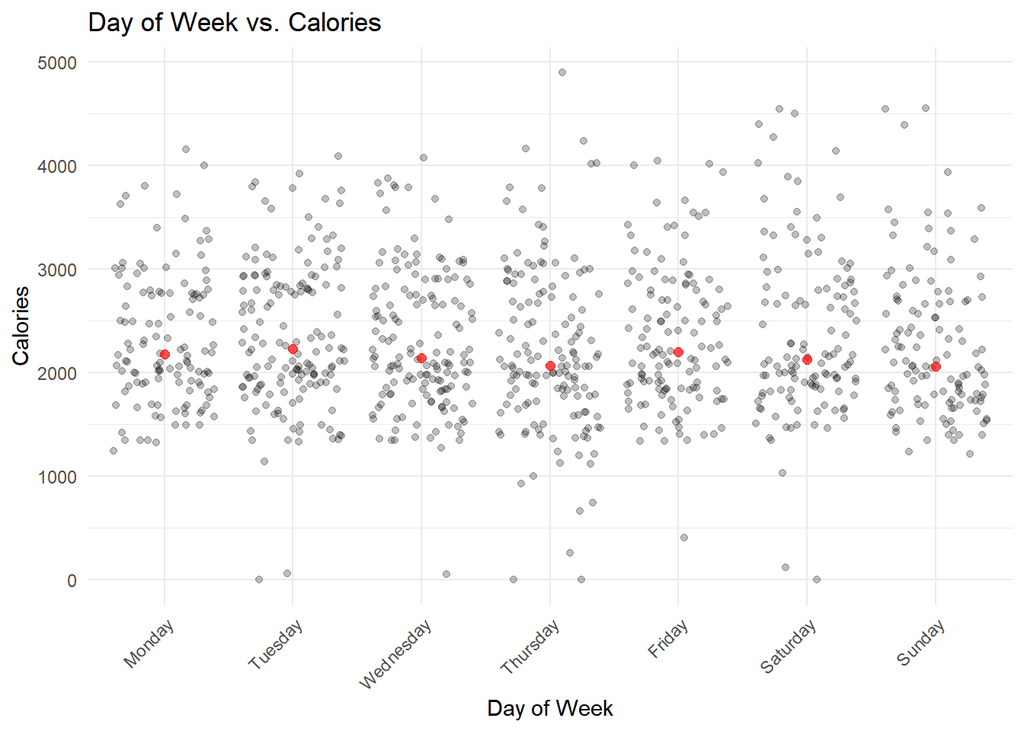

```r
# Visualizing `calories` vs. `day_of_week`
daily_activity %>%
  ggplot(aes(x = day_of_week_ordered, y = calories)) +
  geom_point(position = "jitter", alpha = 0.25) +
  geom_smooth() +
  theme_minimal() +
  labs(title = "Day of Week vs. Calories") +
  xlab("Day of Week") +
  ylab("Calories") +
  stat_summary(
    geom = "point",
    fun = median,
    color = "red",
    size = 2,
    alpha = 0.7
  ) +
  theme(axis.text.x = element_text(angle=45, vjust=1, hjust=1))
```

Similar to `very_active_minutes`, there doesn’t seem to be a significant difference in the amount of calories burned relative to the `day_of_week`.

### Displaying Sleep Activity

Next, let’s see how sleep affects daily calories. First, by merging `daily_activity` and `daily_sleep`, and then visualizing whether there is any correlation between `sleep` and `calories`.

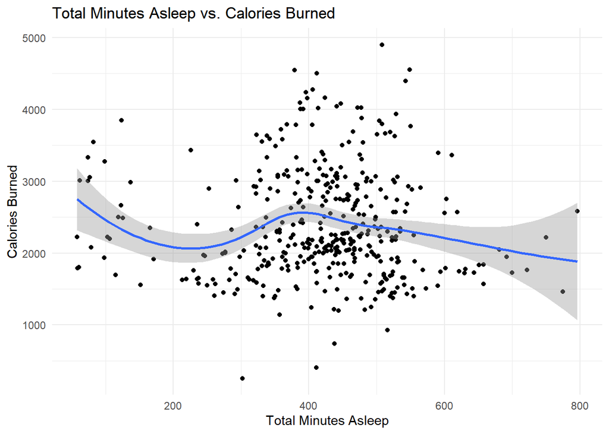

```r
# Merging daily_activity and daily_sleep
daily_activity_sleep_merged <- full_join(daily_activity, daily_sleep, by = c("id", "date", "day_of_week"))
daily_activity_sleep_merged <- daily_activity_sleep_merged[complete.cases(daily_activity_sleep_merged), ]

# Visualizing total minutes asleep vs. calories burned daily
daily_activity_sleep_merged %>%
  ggplot(aes(x = total_minutes_asleep, y = calories)) +
  geom_point() +
  geom_smooth() +
  theme_minimal() +
  labs(title = "Total Minutes Asleep vs. Calories Burned") +
  xlab("Total Minutes Asleep") +
  ylab("Calories Burned")
```

As we can see, there is not a clear correlation on total minutes asleep and calories burned on a daily basis. This does not indicate that sleep is not important to a person’s health though, merely that calories burned are not directly affected.

Let’s check how sleep varies on weekdays in comparison to weekends:

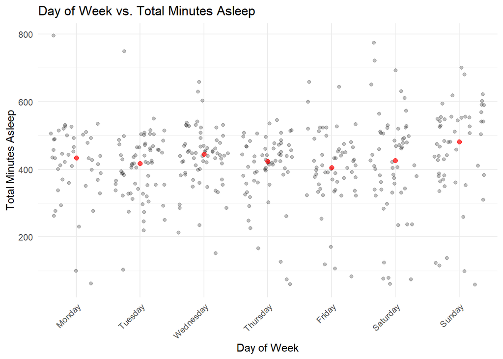

```r
# Visualizing `total_minutes_asleep` vs. `day_of_week`
day_of_week_ordered <- factor(
  daily_activity_sleep_merged$day_of_week,
  levels = c("Monday", "Tuesday", "Wednesday", "Thursday", "Friday", "Saturday", "Sunday")
  )
daily_activity_sleep_merged %>%
  ggplot(aes(x = day_of_week_ordered, y = total_minutes_asleep)) +
  geom_point(position = "jitter", alpha = 0.25) +
  geom_smooth() +
  theme_minimal() +
  labs(title = "Day of Week vs. Total Minutes Asleep") +
  xlab("Day of Week") +
  ylab("Total Minutes Asleep") +
  stat_summary(
    geom = "point",
    fun = median,
    color = "red",
    size = 2,
    alpha = 0.7
  ) +
  theme(axis.text.x = element_text(angle=45, vjust=1, hjust=1))
```

## Share

### Hourly Comparisons

We understand that generally, very active physical activity is incredibly beneficial for burning daily calories, however, how does that vary during the day? Are users burning more calories during the morning or evening? The `hourly_calories`, `hourly_intensities`, and `hourly_steps` data frames can provide important insights into these questions.

First, let’s combine these data frames:

```r
# Merging daily_activity and daily_sleep
hourly_calories_intensities <- full_join(hourly_calories, hourly_intensities, by = c("id", "date", "day_of_week", "time"))
hourly_activity <- full_join(hourly_calories_intensities, hourly_steps, by = c("id", "date", "day_of_week", "time"))
head(hourly_activity)
```

```
## # A tibble: 6 × 8
##       id date       day_of_week time  calories total_intensity average_intensity
##    <dbl> <date>     <chr>       <chr>    <dbl>           <dbl>             <dbl>
## 1 1.50e9 2016-04-12 Tuesday     00:0…       81              20             0.333
## 2 1.50e9 2016-04-12 Tuesday     01:0…       61               8             0.133
## 3 1.50e9 2016-04-12 Tuesday     02:0…       59               7             0.117
## 4 1.50e9 2016-04-12 Tuesday     03:0…       47               0             0
## 5 1.50e9 2016-04-12 Tuesday     04:0…       48               0             0
## 6 1.50e9 2016-04-12 Tuesday     05:0…       48               0             0
## # ℹ 1 more variable: total_steps <dbl>
```

Then, we can see what time users are being very active:

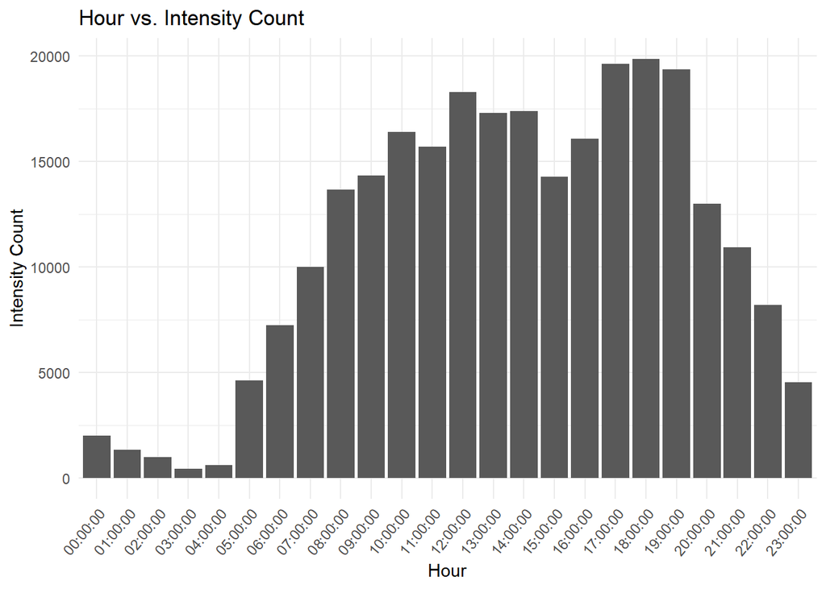

```r
hourly_activity %>%
  ggplot(aes(x = time)) +
  geom_bar(aes(weight = total_intensity), stat = "count") +
  theme_minimal() +
  labs(title = "Hour vs. Intensity Count ") +
  xlab("Hour") +
  ylab("Intensity Count") +
  theme(axis.text.x = element_text(angle=50, vjust=1, hjust=1))
```

From the chart, it seems that around 8:00 AM, users start to be more active, peaking from 5:00 PM to 7:00 PM. It is likely that around this time, users are going to the gym, enduring more active physical activity in comparison to the work day.

Additionally, we can display when users are burning calories throughout the day:

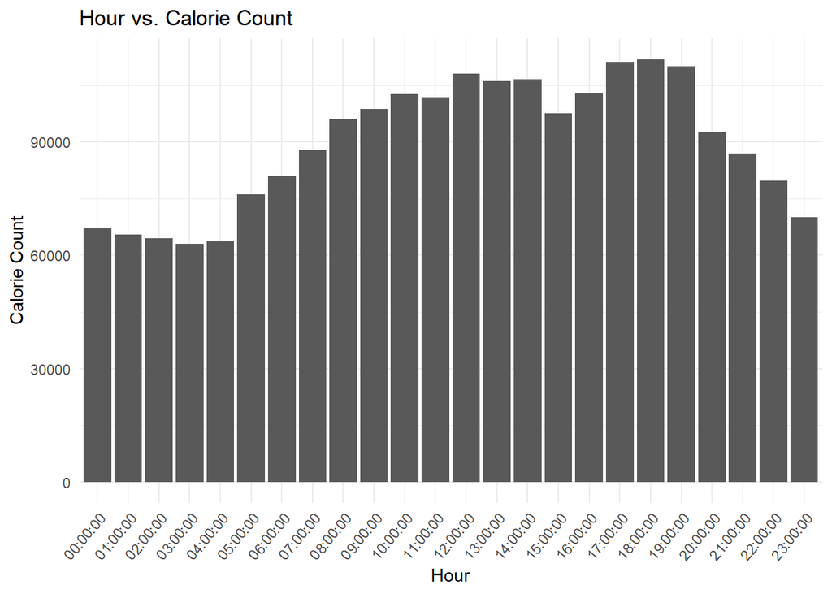

```r
hourly_activity %>%
  ggplot(aes(x = time)) +
  geom_bar(aes(weight = calories), stat = "count") +
  theme_minimal() +
  labs(title = "Hour vs. Calorie Count") +
  xlab("Hour") +
  ylab("Calorie Count") +
  theme(axis.text.x = element_text(angle=50, vjust=1, hjust=1))
```

Similar to the previous chart depicting user intensity by hour, the calories burned seem to peak around 5:00 PM to 7:00 PM. However, there is significant calorie usage early in the day, especially starting from 8:00 AM.

## Act

After completing the key steps of establishing the goals of this case study, preparing the given data for analysis, processing the data, inspecting and cleaning each data set, and analyzing the various trends that emerge from the data, we can provide our recommendations to the Bellabeat Marketing Team as well as how it can be applied to current Bellabeat products.

### Recommendations

**In order to continue Bellabeat’s journey in its growth amidst the global smart device market, we suggest:**

- Highlighting **Time’s** capability to track sleep and user activity. In particular, inform consumers of the significance of **very active physical activity** when burning daily calories.
- Emphasizing ease of use when **Time** is connected to the **Bellabeat app**.
- Reminding users, via the **Bellabeat app** or **Time**, to exercise specifically around **5:00 PM** to **7:00 PM**, as those are the peak hours of recorded physical intensity.
- Calling attention to important metrics for each user, such as their daily step count and amount of time spent on fairly active to very active physical activity, using the **Bellabeat app**. Daily step count can be compared to the recommended goal of **[10,000](https://www.cdc.gov/pcd/issues/2016/pdf/16_0111.pdf) steps**, while goals of weekly minutes of heightened physical activity can reference the [recommended](https://www.who.int/publications/i/item/9789241599979) **150** minutes of moderately active activity or **75** minutes of very active activity. To further encourage users to increase physical activity, a digital point system can be used to compare daily or weekly step goals and physical activity levels to past activity.